# Visualizing the Impact of Palm Oil Production

Wanda Wang

April 24, 2016

## Introduction

Deforestation is accelerating at an alarming rate around the world as a result of Palm oil production. In order to satisfy growing global demand for Palm oil, an ingredient commonly found in cosmetics to processed foods - clearing the way for lucrative oil plantations by forest fires is negatively impacting our environment. Concerns include the loss of rainforest habitat for endangered species, harmful carbon dioxide emissions, coupled with the displacement of local indigenous communities.

## Exploratory Questions

What countries are the top producers of Palm oil? Where are the palm oil mills located? Where are the forest-fire hotspots?

## The Datasets

The UN Food and Agriculture organization provides information on global Palm oil production and area harvested. The Global Forest Watch also has Palm oil Mill location data and fire alert data available for our review.

## Industry Overview

To navigate to where Palm Oil production is at its highest, we first approach the UN Food and Agriculture dataset:

[output not shown]

The top five producers in the world include Indonesia and Malaysia. Indonesia accounts for over 46% or worldwide production. Malaysia accounts for around 34%. The combined 80% allocation in this region should be noted.

## Industry Map - Bird’s eye view

[figure not shown]

```r
library(maptools)
library(ggplot2)
library(ggmap)
library(rgeos)
library(dplyr)
plotmap <- readShapePoly(fn="TM_WORLD_BORDERS-0.3/TM_WORLD_BORDERS-0.3.shp")
palmHa <-read.csv("Faostats.csv", stringsAsFactors=F)
palmHa <-filter(palmHa, ElementName == 'Area harvested')
names(plotmap)[5] <- "AreaName"
target <- c("Indonesia", "Malaysia", "Colombia", "Thailand",
            "Philippines", "Nigeria")
#Use foritfy to transform spatial plotmap into dataframe
plotmapDf <- fortify(plotmap, region = "AreaName") %>%
  filter(id %in% target)
palmHaMapDf <- merge(plotmapDf, palmHa, by.x="id", by.y="AreaName")
backgroundMap <- ggplot(data=palmHaMapDf) + geom_path(aes(x=long, y=lat, group=group), color='grey') + coord_equal() + geom_polygon(aes(x=long, y=lat, group=group, fill=Value))
mapAsia <- get_map(location = 'Indonesia', zoom=4)
mapAfrica <- get_map(location = 'Africa', zoom=4)
mapSouthAm <- get_map(location = 'South America', zoom=4)
ggmapObjAsia <- ggmap(mapAsia)
Asia <- ggmapObjAsia + geom_polygon(aes(x=long, y=lat, group=group, fill=Value), data=palmHaMapDf, alpha=.9) +
  geom_path(aes(x=long, y=lat, group=group), data=palmHaMapDf, color='black')
Asia
```

[figure not shown]

```r
ggmapObjAf <- ggmap(mapAfrica)
Africa <- ggmapObjAf + geom_polygon(aes(x=long, y=lat, group=group, fill=Value), data=palmHaMapDf, alpha=.9) +
  geom_path(aes(x=long, y=lat, group=group), data=palmHaMapDf, color='black')
Africa
```

[figure not shown]

```r
ggmapSouthAm <- ggmap(mapSouthAm)
SouthAm <- ggmapSouthAm + geom_polygon(aes(x=long, y=lat, group=group, fill=Value), data=palmHaMapDf, alpha=.9) +
  geom_path(aes(x=long, y=lat, group=group), data=palmHaMapDf, color='black')
SouthAm
```

As a visual confirmation on the map - looking at SouthEast Asia vs Africa or South America, there are more acres harvested within Indonesia.

## Palm Oil Harvested in Indonesia

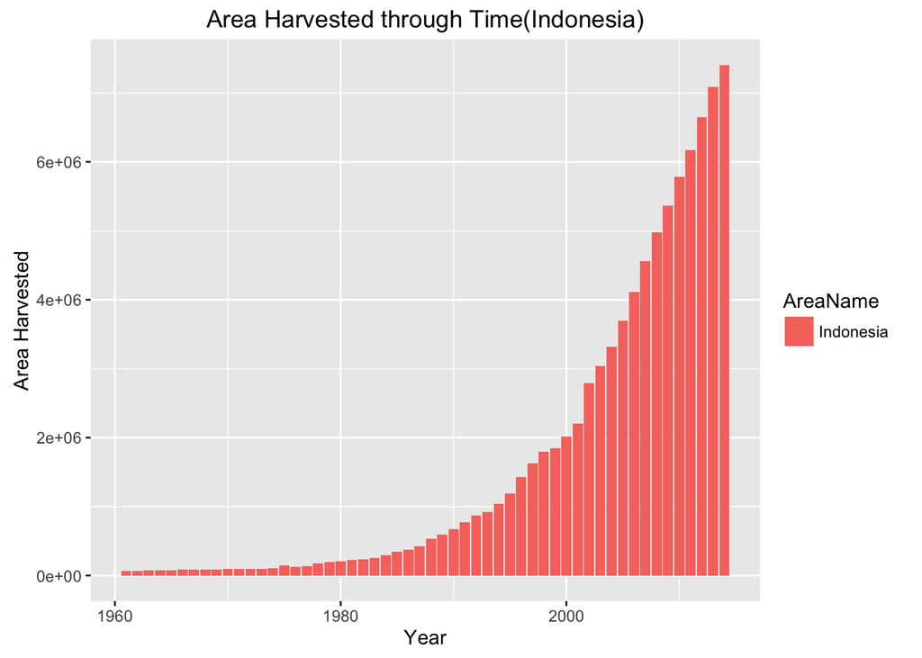

```r
library(dplyr)
library(ggplot2)
faostat.palm <-read.csv("Faostats.csv")
faostat.palm <- faostat.palm %>% na.omit()
AH<-filter(faostat.palm, ElementName=='Area harvested', AreaName=='Indonesia')

areaGraph<-ggplot(AH, aes(Year, Value, fill=AreaName)) + geom_bar(stat="identity") +
  ylab("Area Harvested") + ggtitle("Area Harvested through Time(Indonesia)")
areaGraph
```

## Mill Distribution and Fire Hotspots

[output not shown]

## Conclusion

There is a strong presence of fire hotspots where the majority of Mills are located. ##Future Questions Are there any geographic overlaps with existing nature reservations- what is the deforestation risk in those areas? How much has the Air Quality Index been impacted? Which exact species are threatened in each country’s province?